# **E-NEWS EXPRESS**!

[figure not shown]

## **Problem Statement**

### **Business Context**

The advent of e-news, or electronic news, portals has offered us a great opportunity to quickly get updates on the day-to-day events occurring globally. The information on these portals is retrieved electronically from online databases, processed using a variety of software, and then transmitted to the users. There are multiple advantages of transmitting new electronically, like faster access to the content and the ability to utilize different technologies such as audio, graphics, video, and other interactive elements that are either not being used or aren’t common yet in traditional newspapers.

E-news Express, an online news portal, aims to expand its business by acquiring new subscribers. With every visitor to the website taking certain actions based on their interest, the company plans to analyze these actions to understand user interests and determine how to drive better engagement. The executives at E-news Express are of the opinion that there has been a decline in new monthly subscribers compared to the past year because the current webpage is not designed well enough in terms of the outline & recommended content to keep customers engaged long enough to make a decision to subscribe.

[Companies often analyze user responses to two variants of a product to decide which of the two variants is more effective. This experimental technique, known as A/B testing, is used to determine whether a new feature attracts users based on a chosen metric.]

### **Objective**

The design team of the company has researched and created a new landing page that has a new outline & more relevant content shown compared to the old page. In order to test the effectiveness of the new landing page in gathering new subscribers, the Data Science team conducted an experiment by randomly selecting 100 users and dividing them equally into two groups. The existing landing page was served to the first group (control group) and the new landing page to the second group (treatment group). Data regarding the interaction of users in both groups with the two versions of the landing page was collected. Being a data scientist in E-news Express, you have been asked to explore the data and perform a statistical analysis (at a significance level of 5%) to determine the effectiveness of the new landing page in gathering new subscribers for the news portal by answering the following questions:

- Do the users spend more time on the new landing page than on the existing landing page?
- Is the conversion rate (the proportion of users who visit the landing page and get converted) for the new page greater than the conversion rate for the old page?
- Does the converted status depend on the preferred language?
- Is the time spent on the new page the same for the different language users?

### **Data Dictionary**

The data contains information regarding the interaction of users in both groups with the two versions of the landing page.

`user_id` - Unique user ID of the person visiting the website

`group` - Whether the user belongs to the first group (control) or the second group (treatment)

`landing_page` - Whether the landing page is new or old

`time_spent_on_the_page` - Time (in minutes) spent by the user on the landing page

`converted` - Whether the user gets converted to a subscriber of the news portal or not

`language_preferred` - Language chosen by the user to view the landing page

### **Import the necessary libraries**

```python
# Libraries to help with reading and manipulating data
import numpy as np
import pandas as pd

# Libraries to help with data visualization
import matplotlib.pyplot as plt
import seaborn as sns
%matplotlib inline

# Library to help with statistical analysis
import scipy.stats as stats
```

### **Loading the dataset**

```python
from google.colab import drive
drive.mount('/content/drive')
```

```python
data = pd.read_csv("/content/drive/MyDrive/Applied_Statistics_Project/abtest.csv")
```

```python
# copying data to another variable to avoid any changes to original data
df = data.copy()
```

### **Understanding the structure of the data**

```python
# looking at head (5 observations)
df.head()
```

|  | user_id | group | landing_page | time_spent_on_the_page | converted | language_preferred |
| --- | --- | --- | --- | --- | --- | --- |
| 0 | 546592 | control | old | 3.48 | no | Spanish |
| 1 | 546468 | treatment | new | 7.13 | yes | English |
| 2 | 546462 | treatment | new | 4.40 | no | Spanish |
| 3 | 546567 | control | old | 3.02 | no | French |
| 4 | 546459 | treatment | new | 4.75 | yes | Spanish |

```python
#Checking the shape of the dataset
df.shape
```

```
(100, 6)
```

**Observation:**

- The dataset has 100 rows and 6 columns.

```python
#Checking the data types of the columns for the dataset
df.info()
```

```
<class 'pandas.core.frame.DataFrame'>
RangeIndex: 100 entries, 0 to 99
Data columns (total 6 columns):
 #   Column                  Non-Null Count  Dtype
---  ------                  --------------  -----
 0   user_id                 100 non-null    int64
 1   group                   100 non-null    object
 2   landing_page            100 non-null    object
 3   time_spent_on_the_page  100 non-null    float64
 4   converted               100 non-null    object
 5   language_preferred      100 non-null    object
dtypes: float64(1), int64(1), object(4)
memory usage: 4.8+ KB
```

**Observations:**

- There are a total of 100 values per column and 6 columns in the dataset.
- The `group`, `landing_page`, `converted` and `language_preferred` columns are of object type while `time_spent_on_the_[age` is numerical in nature.
- `user_id` is for unique identifier for each user.

```python
#Checking is there any null value present or not
df.isnull().sum()
```

```
user_id                   0
group                     0
landing_page              0
time_spent_on_the_page    0
converted                 0
language_preferred        0
dtype: int64
```

**Observations:**

- No null value present in dataset.

```python
#Statistical summary of the dataset
df.describe().T
```

|  | count | mean | std | min | 25% | 50% | 75% | max |
| --- | --- | --- | --- | --- | --- | --- | --- | --- |
| user_id | 100.0 | 546517.0000 | 52.295779 | 546443.00 | 546467.75 | 546492.500 | 546567.2500 | 546592.00 |
| time_spent_on_the_page | 100.0 | 5.3778 | 2.378166 | 0.19 | 3.88 | 5.415 | 7.0225 | 10.71 |

**Observations:**

- A total of 100 entries are included in the dataset
- There is no need to look at the statistical summary of `user_id` as it is a unique identifier number for users.

> Time spent on the page by users:
- The average "time spent on the page" is about 5.38 minutes
- The standard deviation is about 2.38 minutes
- Inter-quartile range includes:

Min = 0.19 min , 25% quartile = 3.88 min , 50% quartile = 5.42 min , 75% quartile = 7.02 min , Max = 10.71 min.

### **Exploratory Data Analysis (EDA)**

**Univariate Analysis**

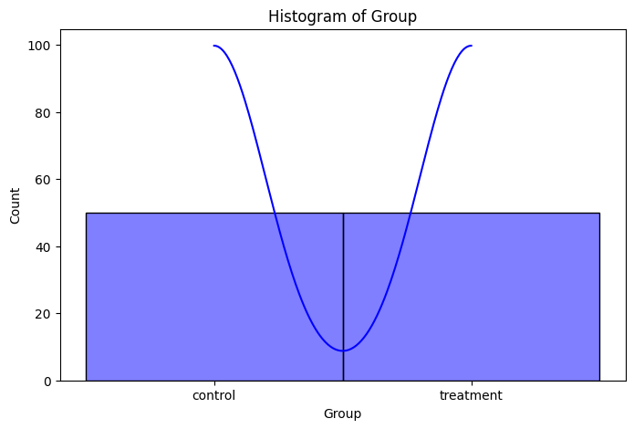

```python
#Observation on group
#Histogram
plt.figure(figsize=(8, 5))
sns.histplot(data = df, x = "group", color='b', kde = True)
plt.title('Histogram of Group')
plt.xlabel('Group')
plt.ylabel('Count')
plt.show()
```

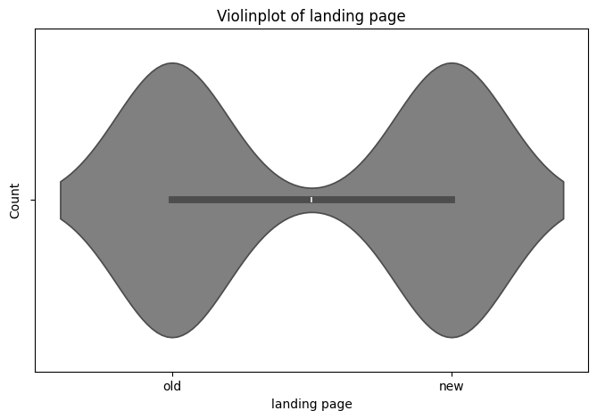

```python
#Observation on landing page
#Histogram
plt.figure(figsize=(8, 5))
sns.violinplot(data = df, x = "landing_page", color='gray')
plt.title('Violinplot of landing page')
plt.xlabel('landing page')
plt.ylabel('Count')
plt.show()
```

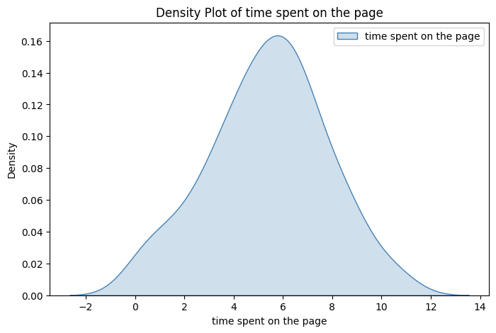

```python
#Observation on time spent on the page
#Density plot
plt.figure(figsize=(8, 5))
sns.kdeplot(df['time_spent_on_the_page'], fill=True, color='steelblue', label='time spent on the page')
plt.title('Density Plot of time spent on the page')
plt.xlabel('time spent on the page')
plt.ylabel('Density')
plt.legend()
plt.show()
```

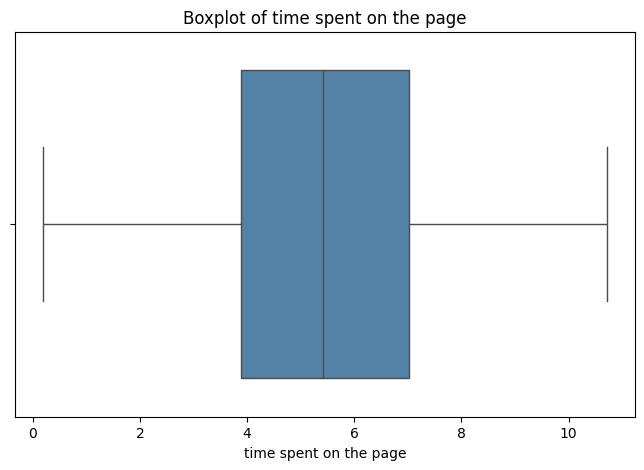

```python
#Observation on time spent on the page
#Box plot
plt.figure(figsize=(8, 5))
sns.boxplot(data=df, x='time_spent_on_the_page', color='steelblue')
plt.title('Boxplot of time spent on the page')
plt.xlabel('time spent on the page')
plt.show()
```

```python
df["time_spent_on_the_page"].describe()
```

```
count    100.000000
mean       5.377800
std        2.378166
min        0.190000
25%        3.880000
50%        5.415000
75%        7.022500
max       10.710000
Name: time_spent_on_the_page, dtype: float64
```

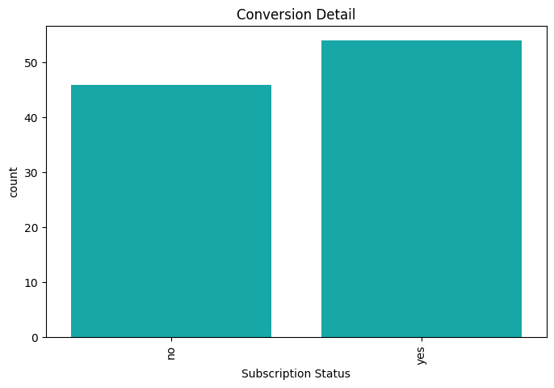

```python
#Observation on Subscription taken or not by user
#Countplot
plt.figure(figsize=(8,5))
sns.countplot(data = df, x = "converted", color = 'c')
plt.title('Conversion Detail')
plt.xlabel('Subscription Status')
plt.xticks(rotation = 90)
plt.show()
```

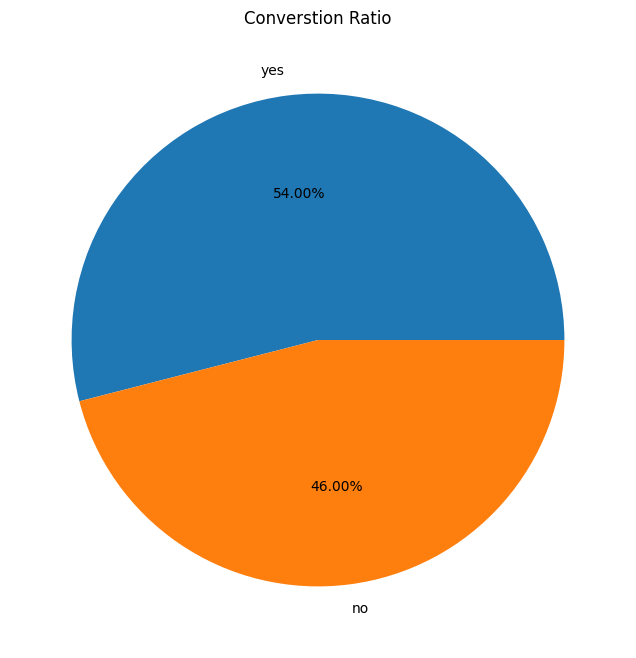

```python
#Pie chart
#User subscribed to webpage or not
converted_count = df['converted'].value_counts()

# Plot a pie chart
plt.figure(figsize=(8, 8))
plt.pie(converted_count, labels=converted_count.index, autopct='%1.2f%%')
plt.title('Converstion Ratio')
plt.show()
```

```python
df["converted"].value_counts()
```

```
converted
yes    54
no     46
Name: count, dtype: int64
```

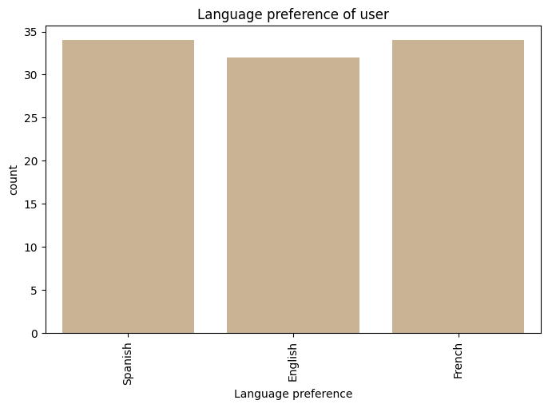

```python
#Observation on Language preferance of user
#Countplot
plt.figure(figsize=(8,5))
sns.countplot(data = df, x = "language_preferred", color = 'tan')
plt.title('Language preference of user')
plt.xlabel('Language preference')
plt.xticks(rotation = 90)
plt.show()
```

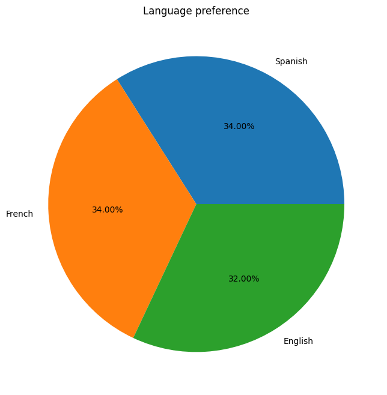

```python
#Pie chart
#User subscribed to webpage or not
language_count = df['language_preferred'].value_counts()

# Plot a pie chart
plt.figure(figsize=(8, 8))
plt.pie(language_count, labels=language_count.index, autopct='%1.2f%%')
plt.title('Language preference')
plt.show()
```

```python
df['language_preferred'].value_counts()
```

```
language_preferred
Spanish    34
French     34
English    32
Name: count, dtype: int64
```

**Bivariate Analysis**

- **Both Categorical Variables**

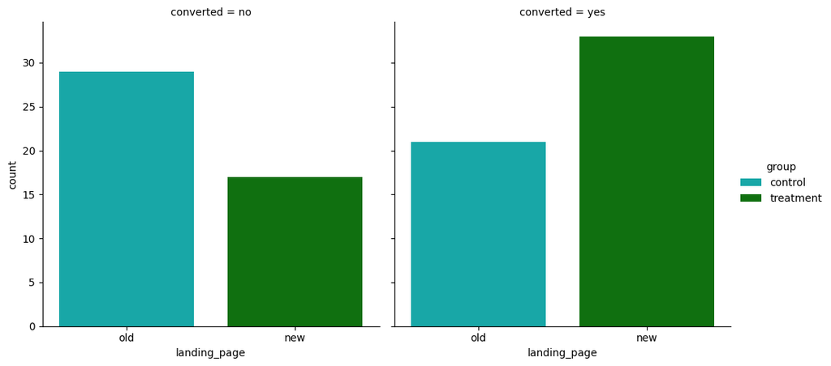

```python
sns.catplot(data=df, x='landing_page', hue='group', col = 'converted', kind = 'count', palette={'control': 'c', 'treatment': 'g'})
```

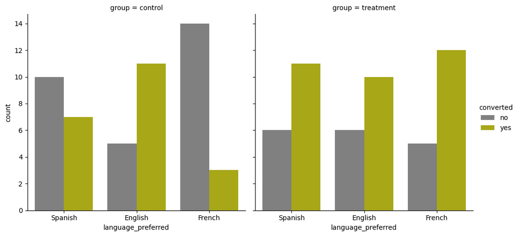

```python
sns.catplot(data = df, x = 'language_preferred', hue = 'converted', col = 'group', kind = 'count', palette={'no': 'gray', 'yes': 'y'})
```

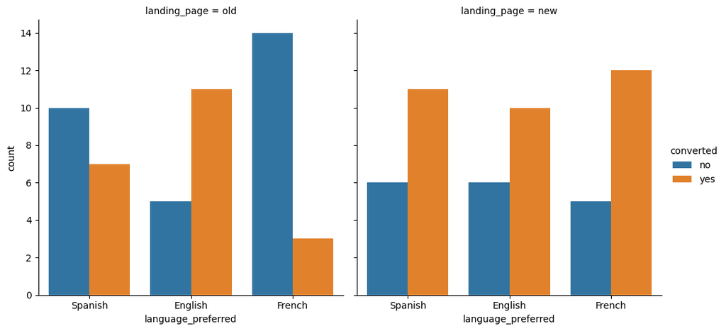

```python
sns.catplot(data = df, x = 'language_preferred', hue = 'converted', col = 'landing_page', kind = 'count')
```

- **Categorical vs Numerical Variables**

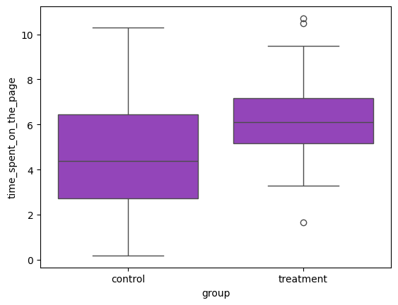

```python
#Observation on group vs. time_spent_on_the_page
sns.boxplot(data=df, y='time_spent_on_the_page',	x='group', color= 'darkorchid')
```

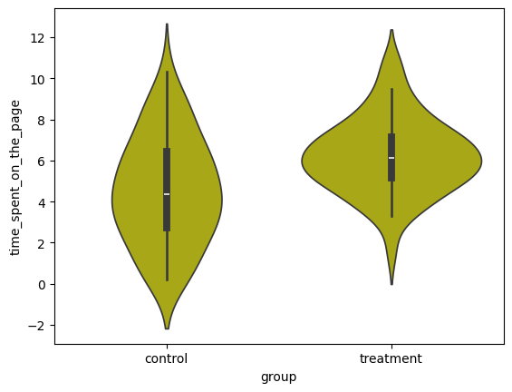

```python
sns.violinplot(data=df, y='time_spent_on_the_page',	x='group', color= 'y')
```

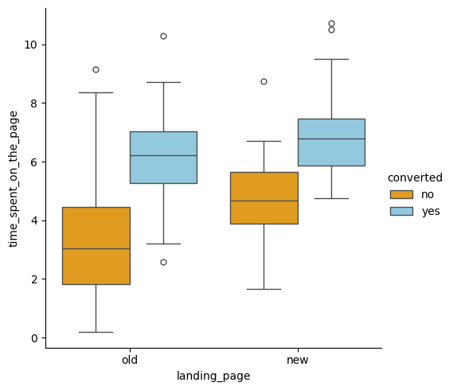

```python
#Observation on landing_page vs. time_spent_on_the_page
sns.catplot(data=df, x='landing_page', y='time_spent_on_the_page', hue='converted', kind='box', palette={'yes': 'skyblue', 'no': 'orange'})
```

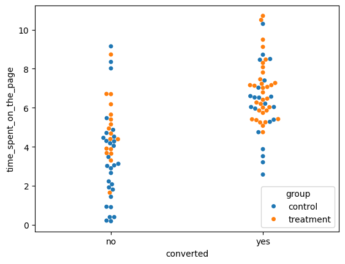

```python
#Observation on converted vs. time_spent_on_the_page
sns.swarmplot(data=df, x='converted', y='time_spent_on_the_page', hue='group')
```

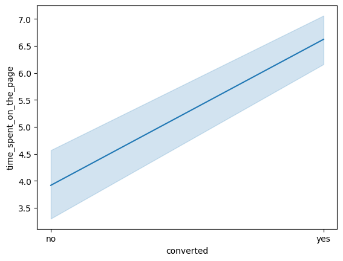

```python
#Observation on time_spent_on_the_page
sns.lineplot(data=df, y='time_spent_on_the_page', x='converted')
```

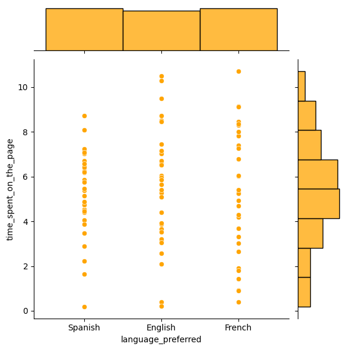

```python
#Observation on language_preferred vs. time_spent_on_the_page
sns.jointplot(data=df, x='language_preferred', y='time_spent_on_the_page', color= 'orange')
```

- **Bothe Numerical Variables**

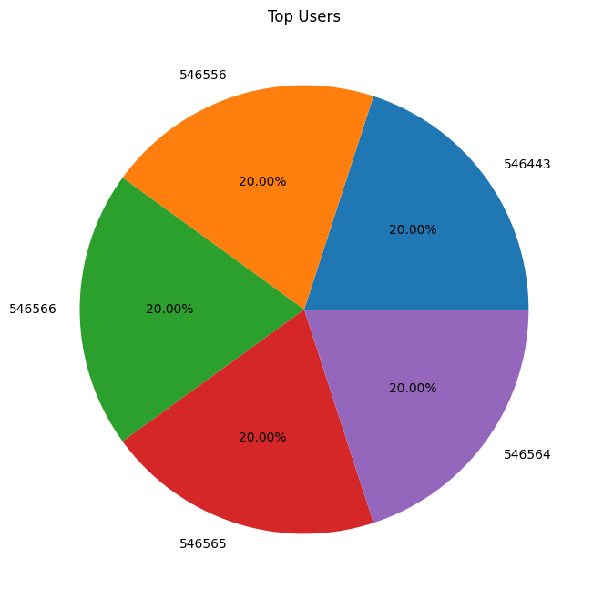

```python
top_users = (df.groupby('user_id')['time_spent_on_the_page'].count()).sort_values(ascending=False).head(5)

# Plot a pie chart
plt.figure(figsize=(8, 8))
plt.pie(top_users, labels=top_users.index, autopct='%1.2f%%')
plt.title('Top Users')
plt.show()
```

```python
top_users
```

```
user_id
546443    1
546556    1
546566    1
546565    1
546564    1
Name: time_spent_on_the_page, dtype: int64
```

### **EDA Insights**

> The feature "group" has 2 unique values control and treatment groups. Group are equally divided.

> The feature "landing page" also has 2 unique values old and new landing page. The data gives 50 observations for the old landing page and 50 observation for the new landing page.

> The observation on "time spent on the page":
- The average time spent on page is about 5.38 minutes
- The standard deviation is about 2.38 minutes
- Inter-quartile range extracted from above codes.
- The data seems to follow a normal distribution as seen on the kdeplot.

> Around 54 % users took sebscription and its not that much good ratio.

> `Spanish` and `French` has high language preference frequncy over `English`.

> There is more subscription taken by treatment group on new landing page. It clearly gives inference about the new landing page is more effective than old landing page.

> The treatment group(those exposed to the new landing page) are more likely to spend more time on the page.

> Users exposed to the new landing page spend more time on average than those on the old landing page.

> From the different languages English, French, and Spanish the average time spent on the page relatively the same.

### **Do the users spend more time on the new landing page than on the existing landing page?**

```python
(df.groupby('landing_page')['time_spent_on_the_page']).mean()
```

```
landing_page
new    6.2232
old    4.5324
Name: time_spent_on_the_page, dtype: float64
```

**Step 1: Define null and alternative hypotheses**

Let μ1,μ2 be the mean time spent on the old landing page vs the mean time spent on the new landing page.

> $H_0$ : μ1 = μ2 , The mean time spent on the old landing page is equal to the new landing page.

> $H_a$: μ1 < μ2 , The mean time spent on the old landing page is less than the new landing page.

**Step 3: Decide the significance level**

As given in the problem statement, we select 𝛼 = 0.05.

```python
mu1 = df[df['landing_page']=='old']['time_spent_on_the_page']
mu2 = df[df['landing_page']=='new']['time_spent_on_the_page']
```

```python
# find the p-value
test_stat, p_value  = stats.ttest_rel(mu2, mu1, alternative = 'greater')  #Performing a paired t-test

print('The p-value is', p_value)
```

```
The p-value is 0.00029910900937037973
```

**Step 5: Compare the p-value with 𝛼**

```python
# print the conclusion based on p-value
if p_value < 0.05:
    print(f'As the p-value {p_value} is less than the level of significance, we reject the null hypothesis.')
else:
    print(f'As the p-value {p_value} is greater than the level of significance, we fail to reject the null hypothesis.')
```

```
As the p-value 0.00029910900937037973 is less than the level of significance, we reject the null hypothesis.
```

**Step 6: Draw Inference**

At 5% significance level, we reject the null hypothesis. Hence we have enough statistical evidence to say that the new landing page encourages users to spend more time than on the old landing page.

**Conslusion**

- In this scenario, the p value is 0.0002991 which is less than the 0.05. Hence, we reject the null hypothesis.
- It means that the new landing page encourages users to spend more time significantly.

### **Is the conversion rate (the proportion of users who visit the landing page and get converted) for the new page greater than the conversion rate for the old page?**

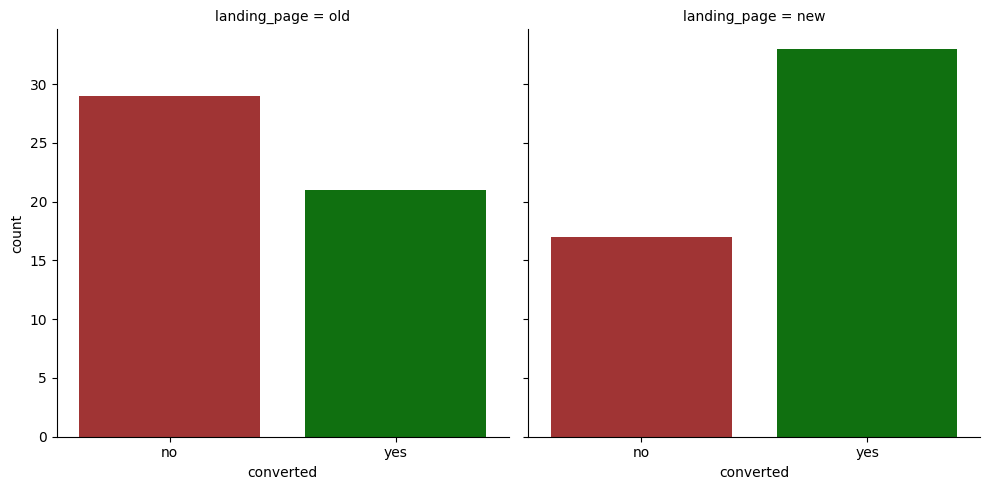

```python
sns.catplot(data = df, x = 'converted', col = 'landing_page', kind = 'count', palette={'yes': 'g', 'no': 'firebrick'})
```

```python
(df.groupby('landing_page')['converted']).value_counts()
```

```
landing_page  converted
new           yes          33
              no           17
old           no           29
              yes          21
Name: count, dtype: int64
```

**Define null and alternative hypotheses**

Let 𝑝1,𝑝2 be the proportions of converters in old landing page and new landing page respectively.

> $H_0$: 𝑝1 = 𝑝2 , Conversion rate of old page and new page is similar.

> $H_a$: 𝑝1 ≠ 𝑝2 , Conversion rate of old page and new page is different.

```python
from statsmodels.stats.proportion import proportions_ztest

# set the counts of converters
converter_count = np.array([21, 33])

# set the sample sizes
nobs = np.array([50, 50])

# find the p-value
test_stat, p_value = proportions_ztest(converter_count, nobs)
print('The p-value is ' + str(p_value))
```

```
The p-value is 0.016052616408112556
```

**Compare the p-value with 𝛼**

```python
# print the conclusion based on p-value
if p_value < 0.05:
    print(f'As the p-value {p_value} is less than the level of significance, we reject the null hypothesis.')
else:
    print(f'As the p-value {p_value} is greater than the level of significance, we fail to reject the null hypothesis.')
```

```
As the p-value 0.016052616408112556 is less than the level of significance, we reject the null hypothesis.
```

**Draw Inference**

At 5% significance level, we reject the null hypothesis. Hence we have enough statistical evidence to say that the conversion rate among the two groups, old landing page and new landing page are different.

**Conslusion**

- In this scenario, the p value is 0.016 which is less than the 0.05. Hence, we reject the null hypothesis.
- It means that the conversion rate among the two groups, old landing page and new landing page are significantly different.

### **Does the converted status depend on the preferred language?**

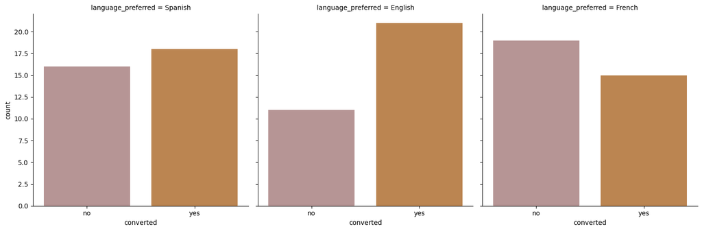

```python
sns.catplot(data = df, x = 'converted', col = 'language_preferred', kind = 'count', palette={'no': 'rosybrown', 'yes': 'peru'})
```

```python
(df.groupby('language_preferred')['converted']).value_counts(normalize=True)
```

```
language_preferred  converted
English             yes          0.656250
                    no           0.343750
French              no           0.558824
                    yes          0.441176
Spanish             yes          0.529412
                    no           0.470588
Name: proportion, dtype: float64
```

```python
df1 = df.drop(['group','user_id','time_spent_on_the_page','landing_page'], axis=1)
df1
```

|  | converted | language_preferred |
| --- | --- | --- |
| 0 | no | Spanish |
| 1 | yes | English |
| 2 | no | Spanish |
| 3 | no | French |
| 4 | yes | Spanish |
| ... | ... | ... |
| 95 | no | Spanish |
| 96 | yes | English |
| 97 | yes | Spanish |
| 98 | yes | Spanish |
| 99 | yes | English |

100 rows × 2 columns

```python
df2 = pd.crosstab(df1['converted'], df1['language_preferred'])
df2
```

| language_preferred converted | English | French | Spanish |
| --- | --- | --- | --- |
| no | 11 | 19 | 16 |
| yes | 21 | 15 | 18 |

**Define null and alternative hypotheses**

> $H_0:$ Converted status is independent of language preferred.

> $H_a:$ Converted status depends on language preferred.

```python
from scipy.stats import chi2_contingency

# find the p-value
chi, p_value, dof, expected = chi2_contingency(df2)
print('The p-value is', p_value)
```

```
The p-value is 0.21298887487543447
```

**Draw Inference**

At 5% significance level, we fail to reject the null hypothesis. Hence we don't have enough statistical evidence to say that converted status depends on language preferrence.

### **Is the mean time spent on the new page same for the different language users?**

```python
df_new_page = df.loc[df['landing_page'] == 'new']
df_new_page.head()
```

|  | user_id | group | landing_page | time_spent_on_the_page | converted | language_preferred |
| --- | --- | --- | --- | --- | --- | --- |
| 1 | 546468 | treatment | new | 7.13 | yes | English |
| 2 | 546462 | treatment | new | 4.40 | no | Spanish |
| 4 | 546459 | treatment | new | 4.75 | yes | Spanish |
| 6 | 546448 | treatment | new | 5.25 | yes | French |
| 8 | 546461 | treatment | new | 10.71 | yes | French |

```python
df_new_page.groupby(['language_preferred'])['time_spent_on_the_page'].mean()
```

```
language_preferred
English    6.663750
French     6.196471
Spanish    5.835294
Name: time_spent_on_the_page, dtype: float64
```

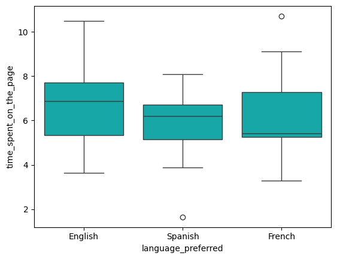

```python
sns.boxplot(data = df_new_page, x = 'language_preferred', y = 'time_spent_on_the_page', color = 'c')
```

**Define null and alternative hypotheses**

Let 𝜇1,𝜇2,𝜇3 be the means of time spent on the new landing page for language preferences English, Spanish and French.

> $H_0$: 𝜇1 = 𝜇2 = 𝜇3 , The average time spent on the new landing page for language preferences English, Spanish and French are equal.

> $H_a$: At least one average time spent on the new landing page is different among the language preferences.

```python
from scipy.stats import f_oneway

test_stat, p_value = f_oneway(df_new_page.loc[df_new_page['language_preferred'] == 'English', 'time_spent_on_the_page'],
                              df_new_page.loc[df_new_page['language_preferred'] == 'Spanish', 'time_spent_on_the_page'],
                              df_new_page.loc[df_new_page['language_preferred'] == 'French', 'time_spent_on_the_page'])
print('The p-value is ' + str(p_value))
```

```
The p-value is 0.43204138694325955
```

**Compare the p-value with 𝛼**

```python
# print the conclusion based on p-value
if p_value < 0.05:
    print(f'As the p-value {p_value} is less than the level of significance, we reject the null hypothesis.')
else:
    print(f'As the p-value {p_value} is greater than the level of significance, we fail to reject the null hypothesis.')
```

```
As the p-value 0.43204138694325955 is greater than the level of significance, we fail to reject the null hypothesis.
```

**Draw Inference**

At 5% significance level, we fail to reject the null hypothesis. Hence we don't have enough statistical evidence to say that at least one average time spent on the new landing page is different among the language preferences.

**Conslusion**